# Spain at a Crossroads

Elections and the political futures ahead

Alberto López Ortega Vrije Universiteit Amsterdam

VICES · Spain at a Crossroads · VU Amsterdam · 18 November 2026

## Spain votes on Sunday 29 November

A **snap election**, called on 5 October.

1. How does the election work?
2. Where does the race stand?
3. What is this election about?
4. Can Sánchez hold on?
5. What is at stake?

## Part 1How does the election work?

## Electoral system

1district in the Netherlands, 150 seats

52districts in Spain, 350 seats

29of them elect five deputies or fewer

## Four kinds of district

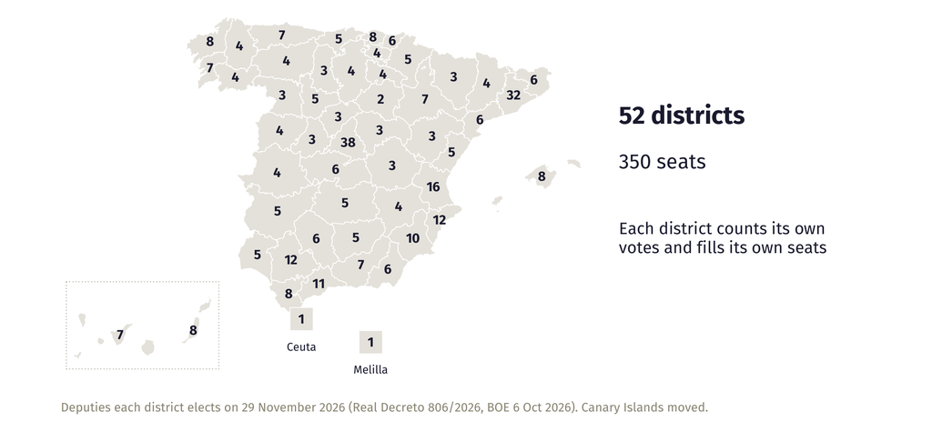

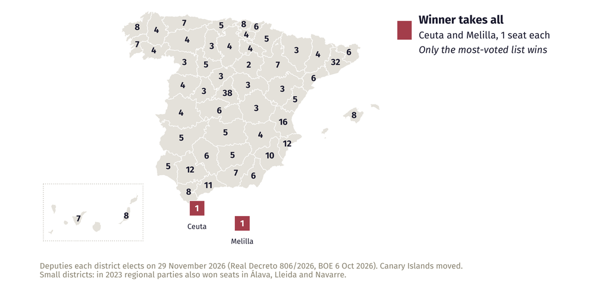

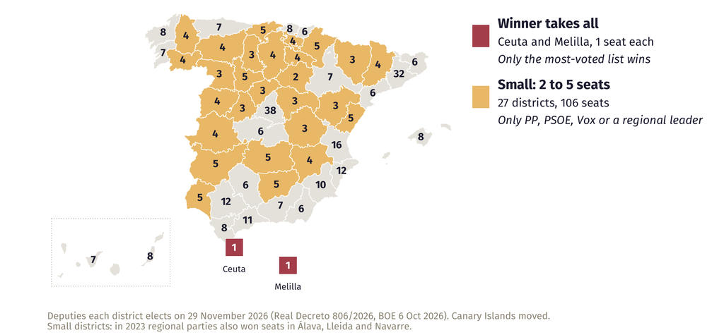

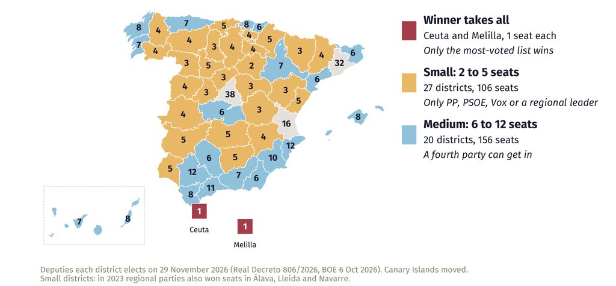

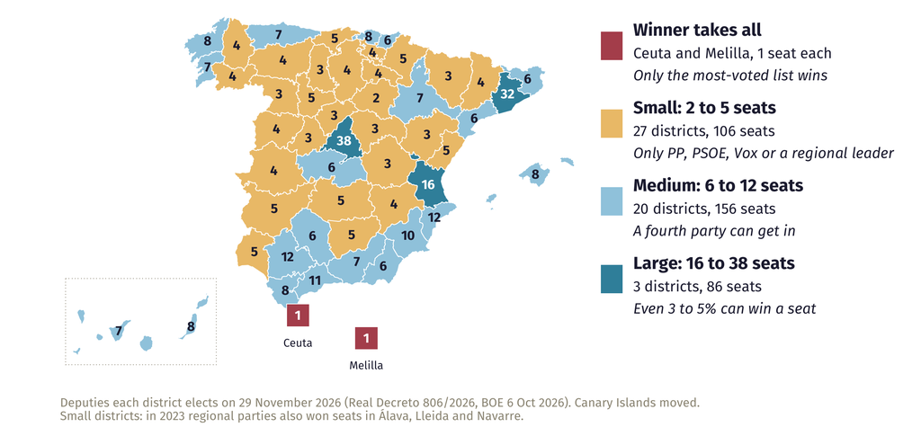

## Vote needed for a seat

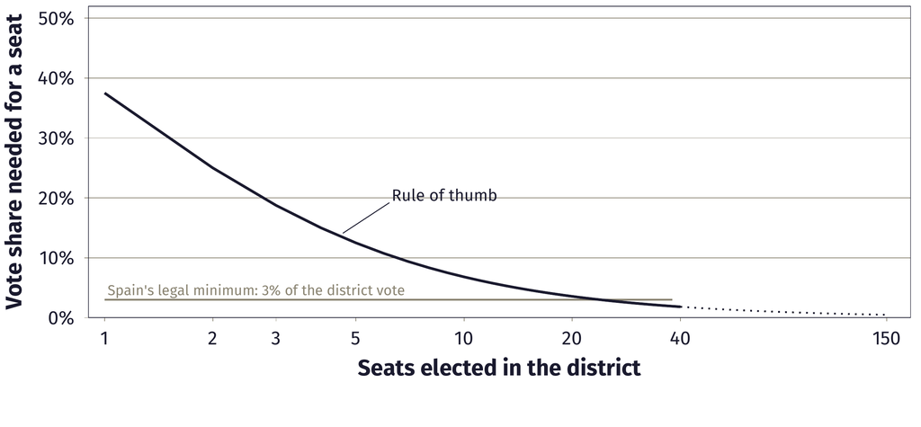

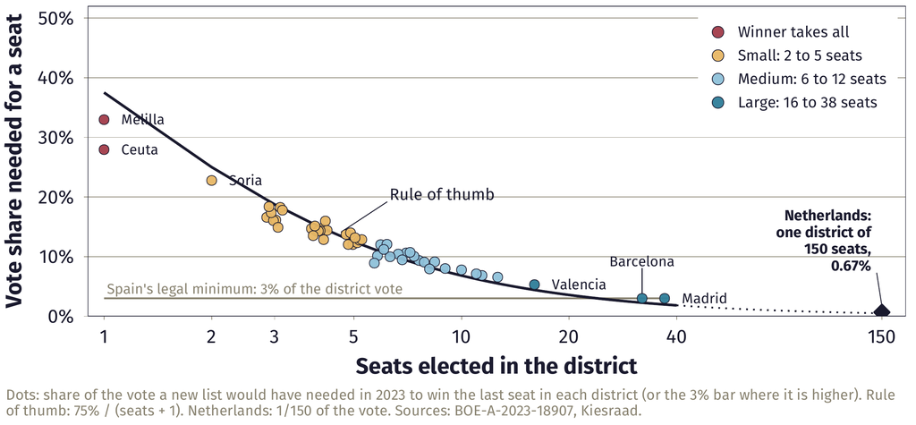

## The 2023 vote in one national district

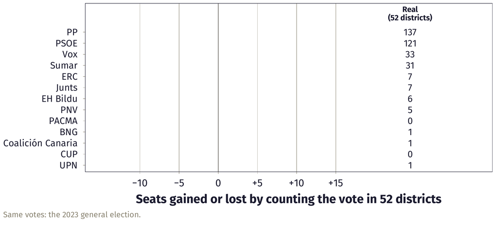

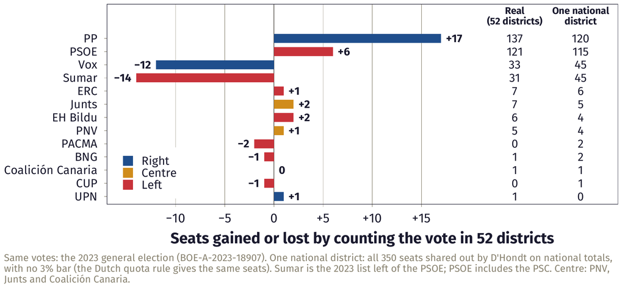

## Fragmentation

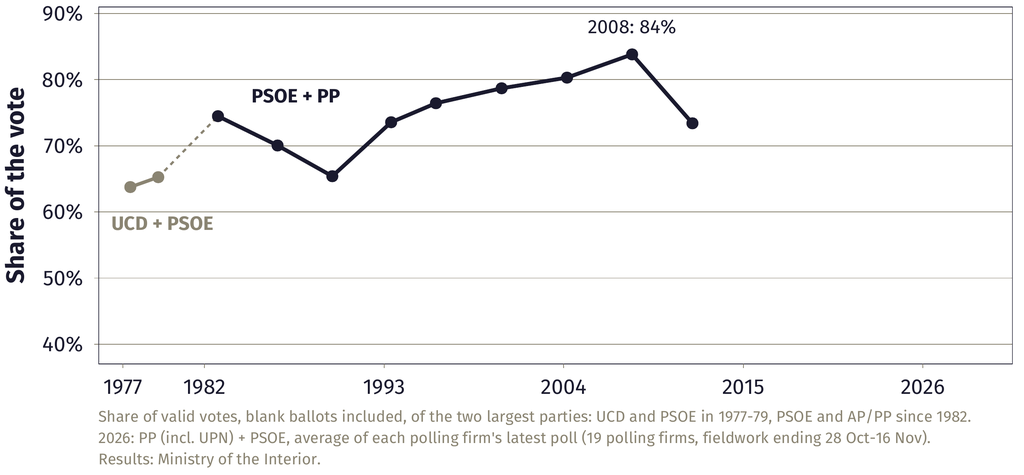

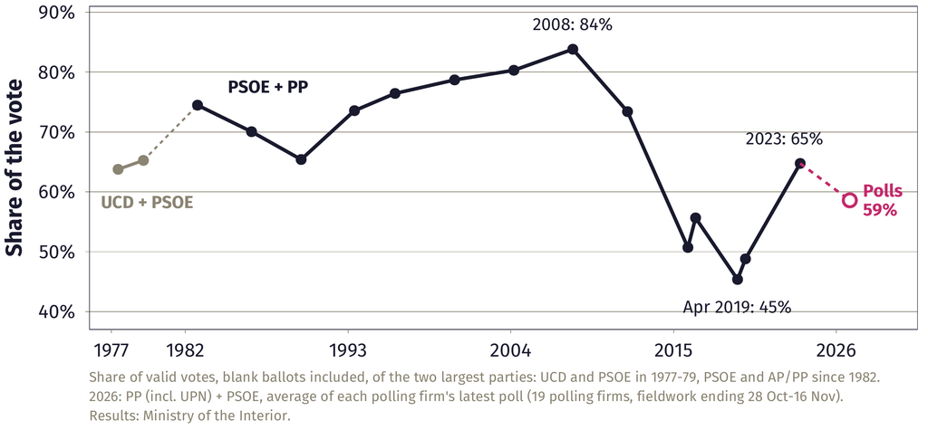

## Parties on the ballot

Statewide, alone everywhere PP · PSOE · Vox

The PP runs with UPN in Navarra. Plus a small national list: **SALF**, Alvise Pérez’s party, in 46 districts.

Built on agreements Frente Amplio (Sumar, IU, Más Madrid, Comuns), with regional partners: Compromís in Valencia and Nueva Canarias (both also with Podemos), Ara Més in the Balearics

ERC with Podemos on its lists new

Podemos alone in 41 districts. Frente Amplio and Podemos face each other in 39 districts that elect 241 deputies.

Regional, no statewide partner Junts · PNV · EH Bildu · BNG · Coalición Canaria · Adelante Andalucía new

Adelante Andalucía runs in all eight Andalusian provinces for the first time (2023: Cádiz only).

534 lists proclaimed in the 52 districts (BOE, 3 Nov 2026): from 5 in Melilla to 14 in Madrid, Álava and Las Palmas. The 2023 Sumar coalition now runs as six separate candidacies.

## Votes that elect nobody

Vox elects deputies in **37 of 52** districts

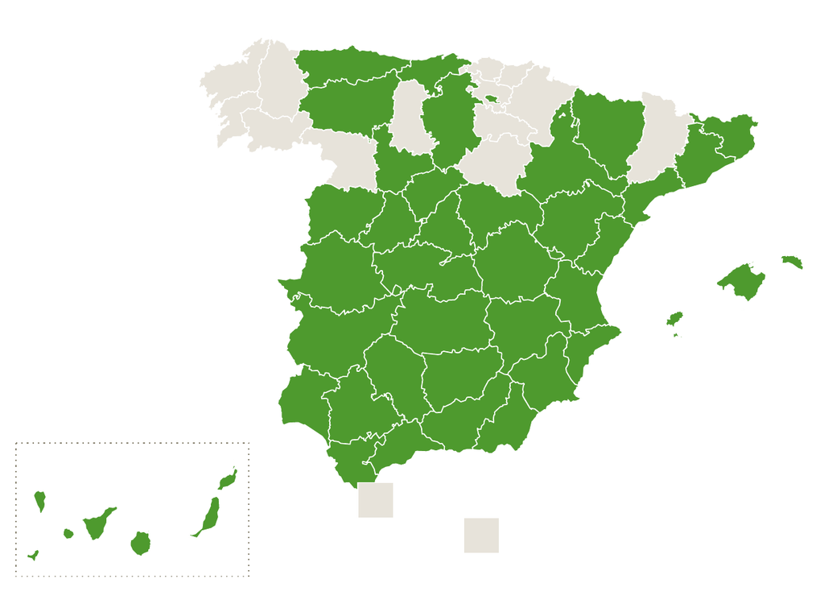

Lists left of the PSOE elect deputies in **6 of 52**

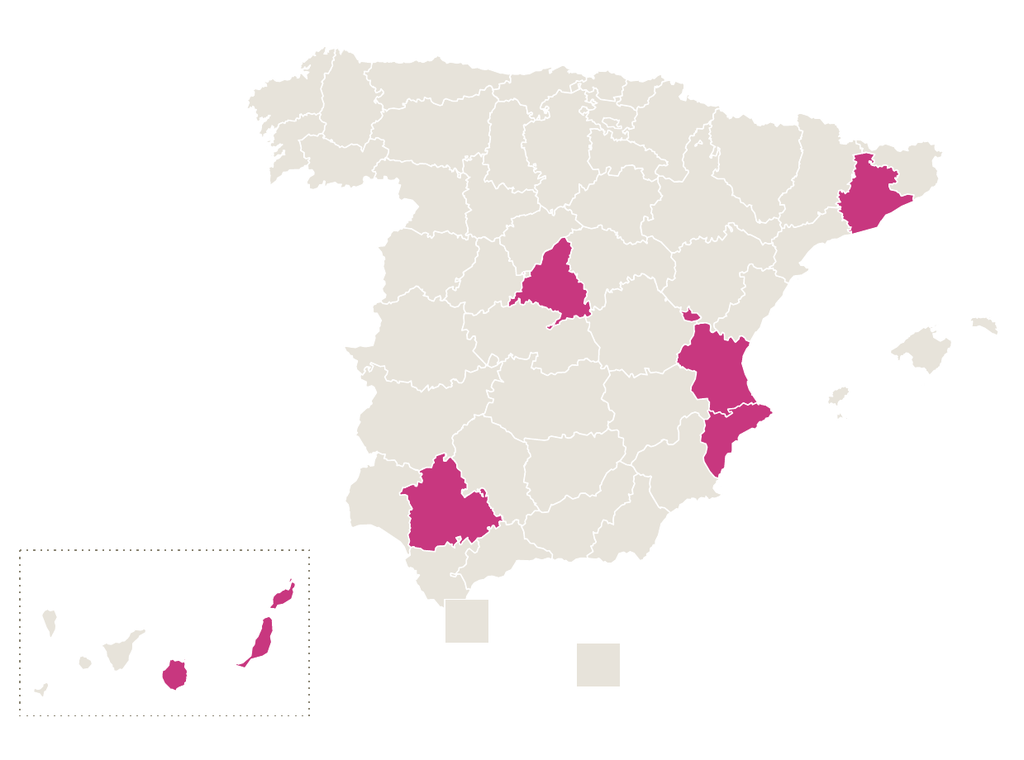

Central projection of my seat model (poll average of 19 polling firms to 16 Nov, D’Hondt by district). “Elect nobody”: votes for a list that wins no seat in its district.

## Part 2Where does the race stand?

## Polls since 2023: the blocs

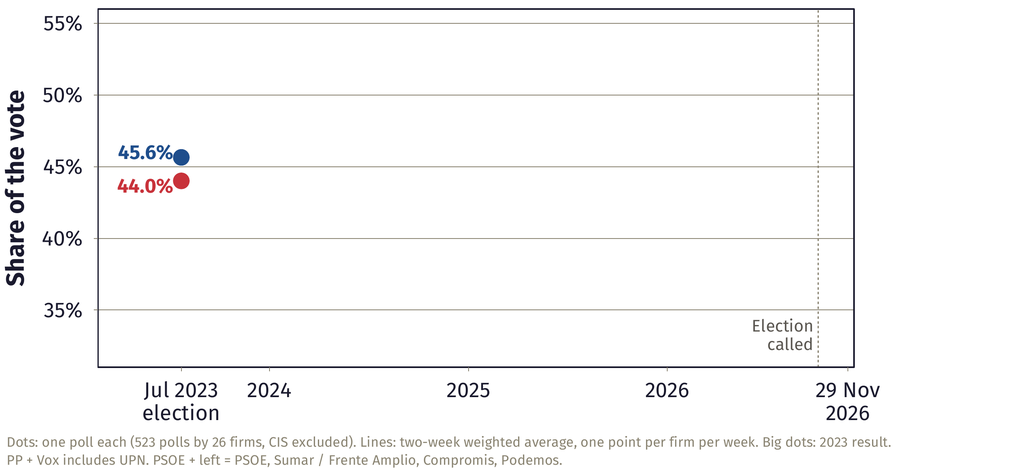

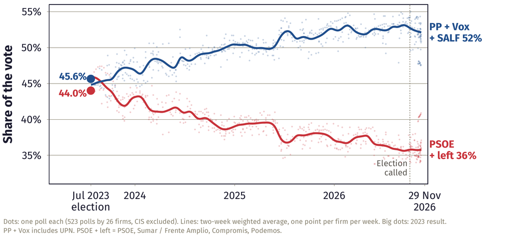

## Polls today: the parties

[figure not shown]

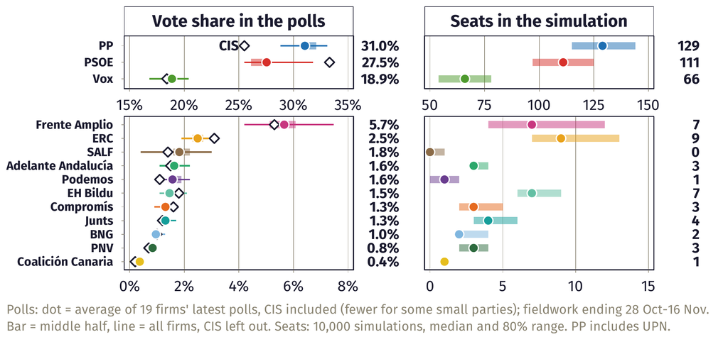

## The 2023 investiture votes

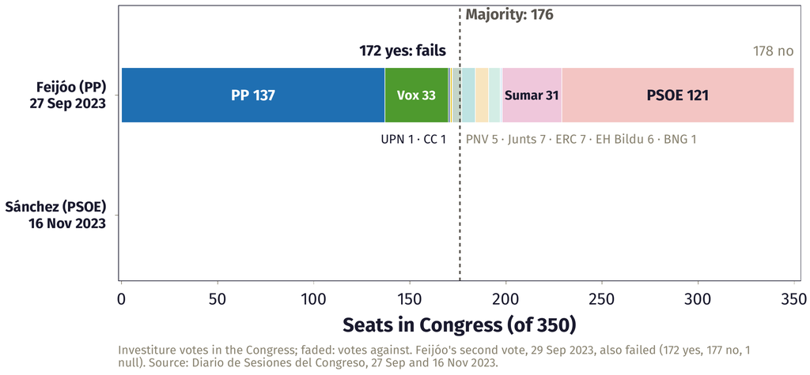

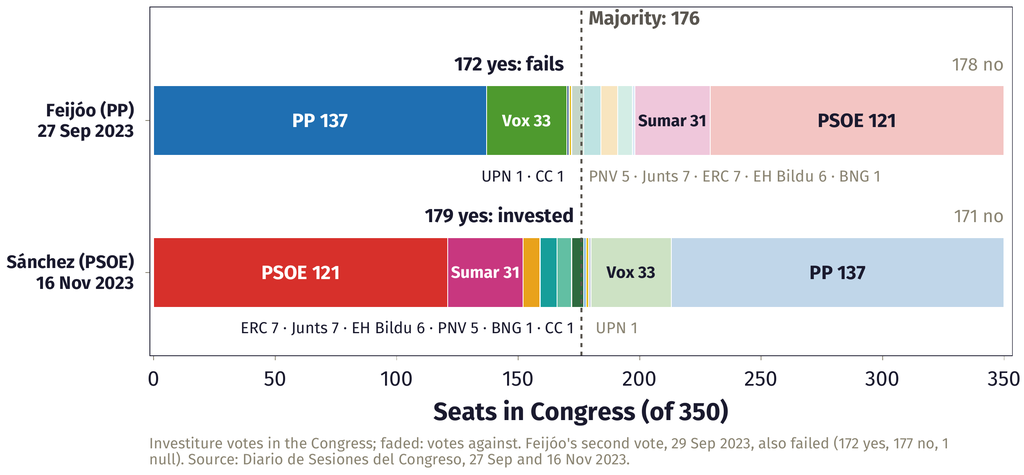

## Seat projections: PP + Vox

[figure not shown]

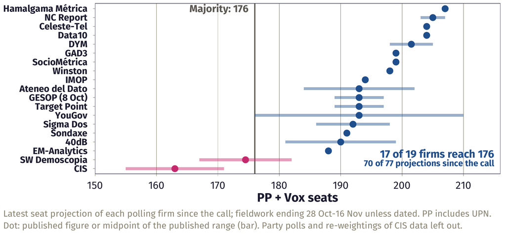

## Campaign trends

[figure not shown]

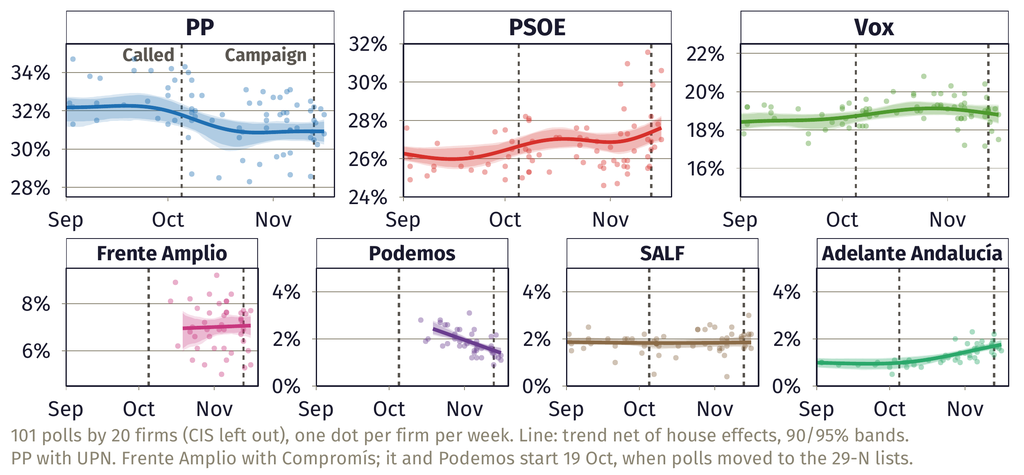

## Simulated Congress

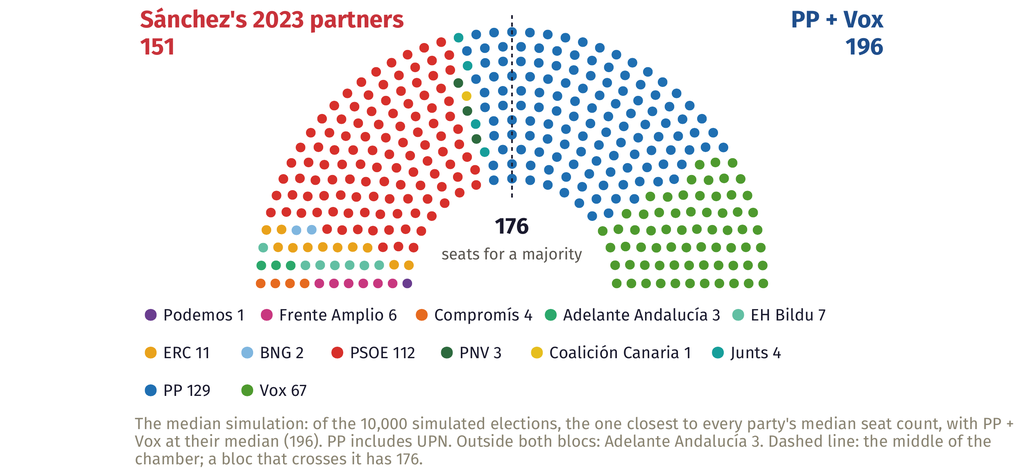

## Scenarios

[figure not shown]

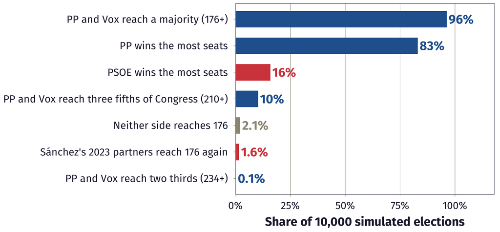

My simulation: 10,000 elections from the poll average, with polling errors as large as those since 1993 and heavy tails. Other models put a PP-Vox majority at 90% (elDiario.es; Kiko Llaneras’s call for a PP-Vox government, El País), 92% (Mapa Electoral), 98% (The Objective) and 99% (El Español / SocioMétrica). SW Demoscopia’s own tracker: 43%.

## Part 3What is this election about?

## Main problems today

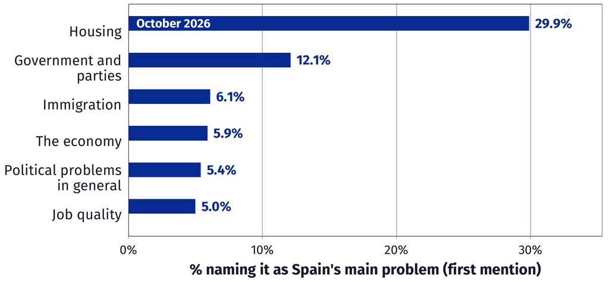

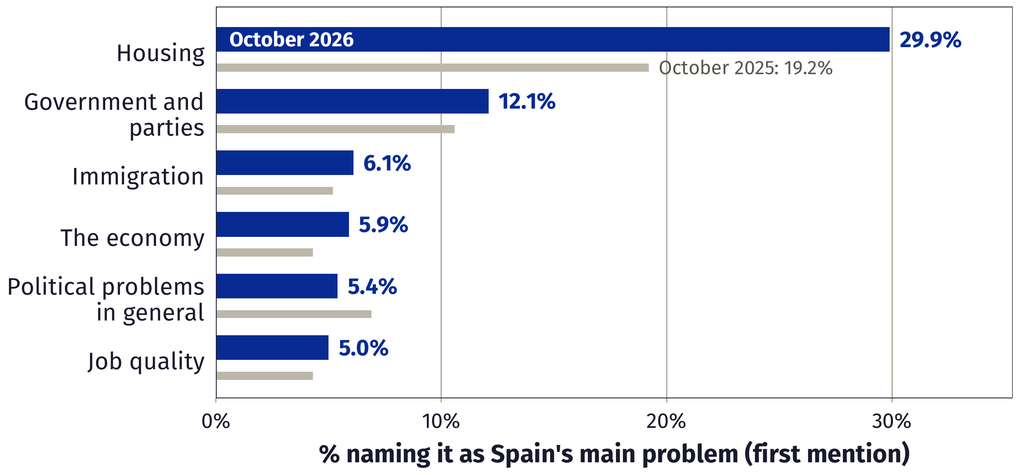

CIS barometers 3582 (1-6 Oct 2026, n = 5,025) and 3528 (Oct 2025, n = 4,029): Spain’s main problem, first spontaneous answer only. The October 2026 survey opened with questions on housing.

## Main problems over time

[figure not shown]

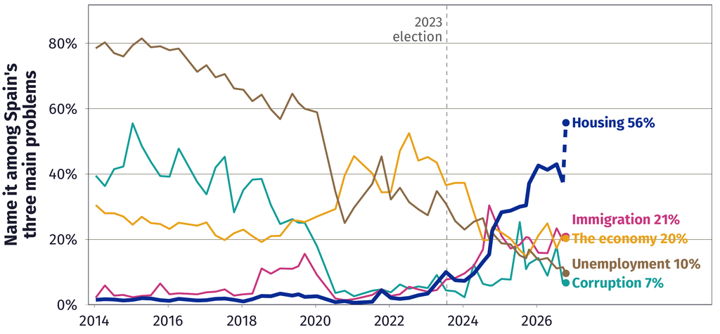

% naming each issue as one of Spain’s three main problems (open question). CIS barometers, one per quarter, Jan 2014-Oct 2026 (studies 3011-3582). Dashed: the October 2026 survey opened with questions on housing. Politics categories changed and are not shown; other issues exist.

## Main problems by party

[figure not shown]

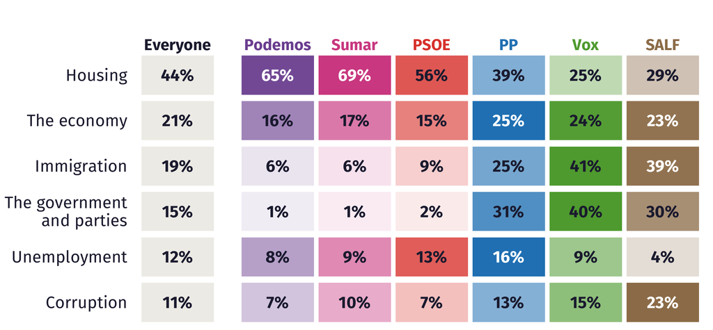

CIS barometers 3540, 3544, 3546, 3557, 3562, 3567, 3571, 3577 and 3582 (Jan-Oct 2026, n = 37,194), CIS weights. % of each party’s voters (direct vote intention) naming the issue as one of Spain’s three main problems (spontaneous answers). Voters: PSOE 8,800; PP 6,937; Vox 3,897; Sumar 1,894; Podemos 883; SALF 490. Colour: share relative to the party highest in each row. Regional parties and other issues not shown. Sumar runs as Frente Amplio.